# Portfolio Project

Author

Quinn Lynas

1. What type of products were the most purchased between 2015 and 2019?
2. What state had the most products purchased?
3. How does the market in California look and has it changed?
4. How are sales distributed between different sub-categories?

**Data Visualization:** I want some sort of time series visualizations so that we can see changes over time. I am guessing a line graph or scatter plot will work well for this, with the date on the x-axis. For my second research question a bar chart will work. For my third research question I will have to visualize using a graph that shows proportion well. I wanted to do a sankey/alluvial plot for this one. Missing data shouldn’t be an issue.

**Data Cleaning:** The data set I am looking at has 9800 rows of information. I will need to fix the zip codes, some of them are missing and some only have 4 digits. I will need to manually fix this. After the zips are fixed, I will match the zip codes with data from the “zipdata” library, which has longitude and latitude information for each zip. I will also be looking at state and overall U.S. longitude and latitude coordinates so that I can answer question 2.

### Data Cleaning

The data set required some fixing with the zip codes. Some of the easterly states who’s zip starts with zero mistakenly read in as only 4 digit zips. I had to put a zero at the front of every zip with that problem. On top of that, one of the cities had missing data for zip code, so I manually coded in the city’s zip. I used a package called “zipcode” which contains a data set with longitude and latitude coordinates for each zip code in the United States. I joined this data set with the original so that each observation had coordinates. I also used the “lubridate” package to format the shipping dates better.

### Visualizations 1 and 2

*Research Question 1:* What type of products were the most sold between 2015 and 2019?

The first two visualizations aim to answer my first research question, seen above. The visualization on the left shows the most sold sub-categories in order from least to most sold. You can see the two most sold products are phones and chairs. The next closest is storage, but the difference between them is quite large. The visualization on the right shows the most sold categories, in order from least to most sold. It is evident that technology sells the most.

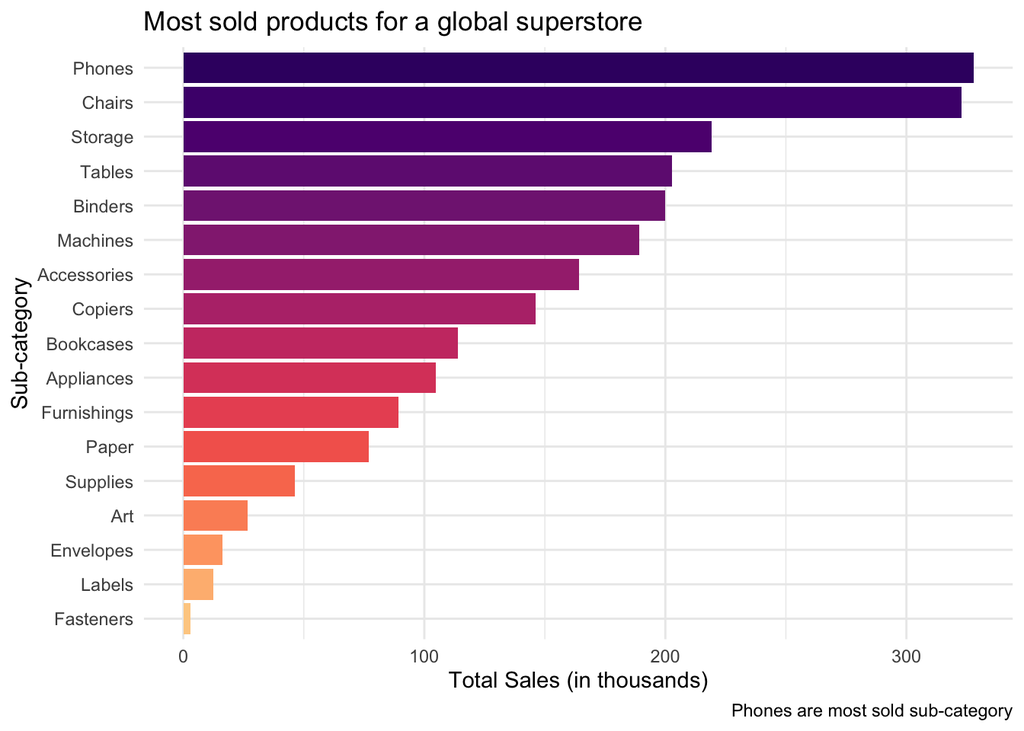

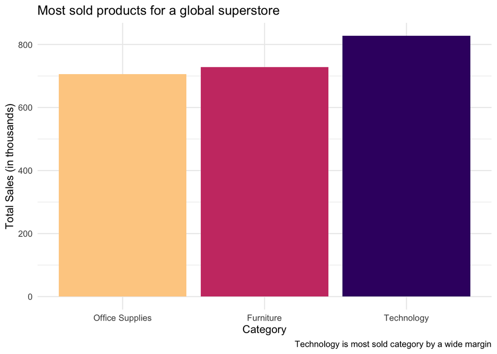

### Visualizations 3, 4, 5, and 6

*Research Question 2:* What state has the most products purchased?

The next four visualizations aim to answer the above research question. The first visualization answers the research question, as you can clearly see California has the most total sales. This visualization and the next only show the states which are top 10 for total sales. The second visualization shows a map of the U.S. and the sales between each of the states. You can see there is a very high density for sales in California, and also states in the Northeast and Midwest. Since I found California had the most sales, I wanted to examine the sales within California to see if they were different than the country’s sales.

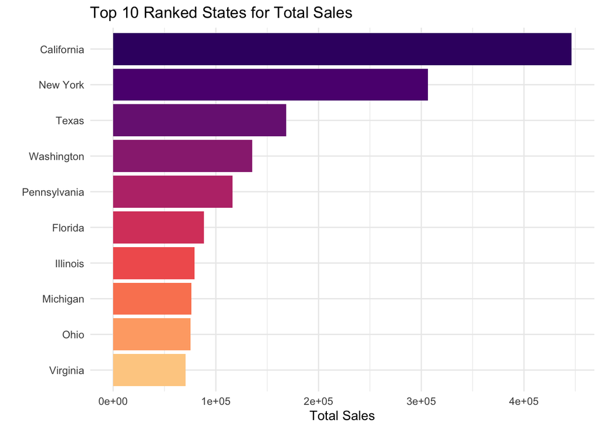

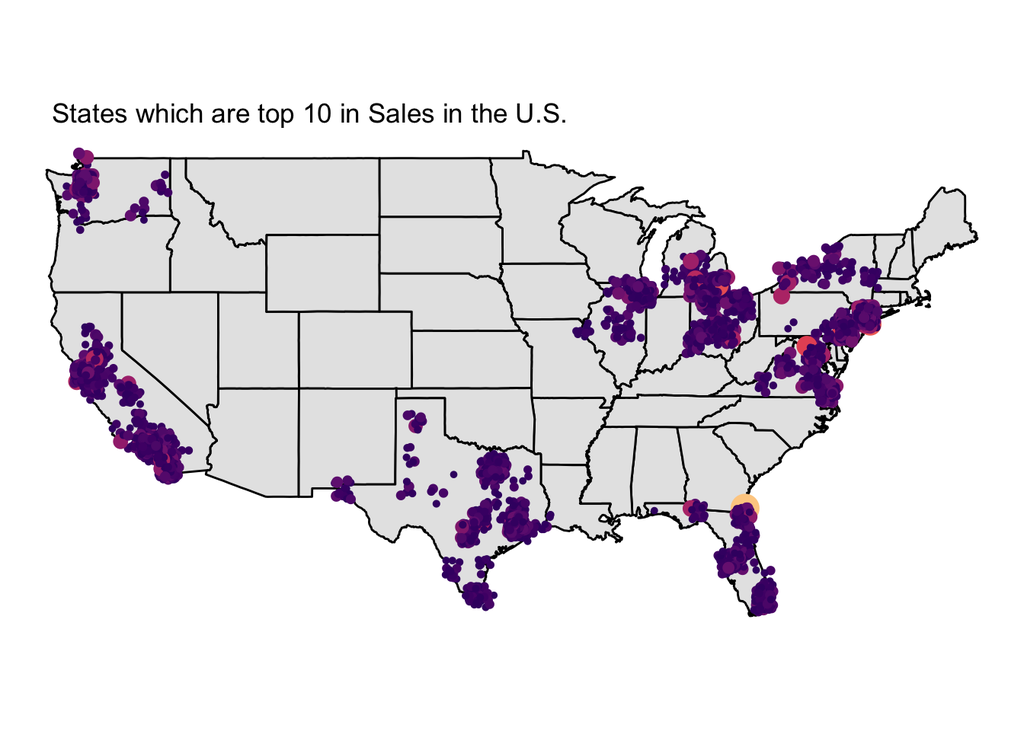

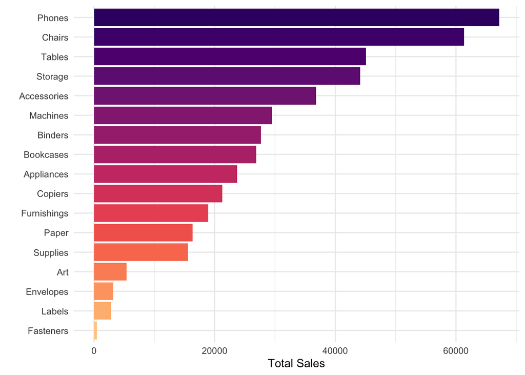

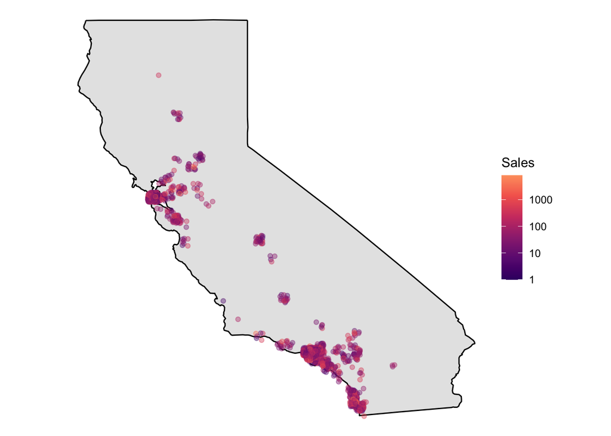

### Visualization 7

*Research Question 3:* How does the market in California look and has it changed?

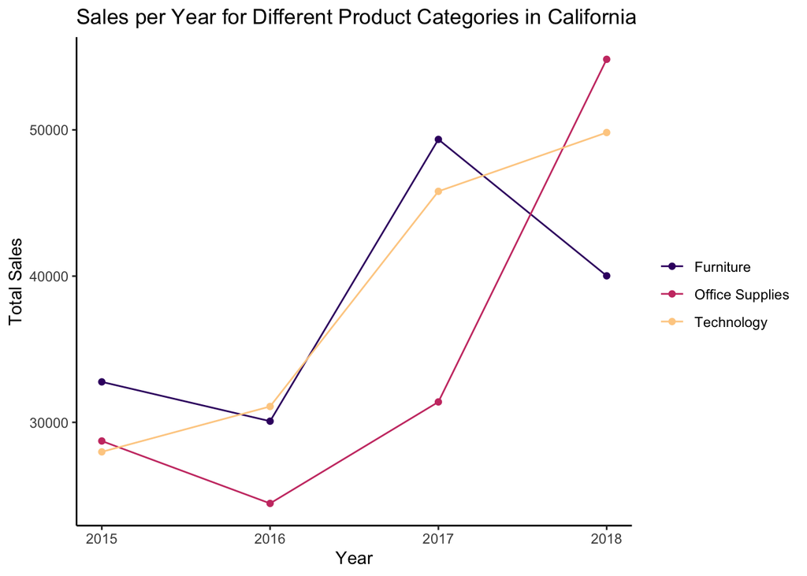

### Visualization 8

*Research Question 4:* How are sales distributed between different sub-categories in California?

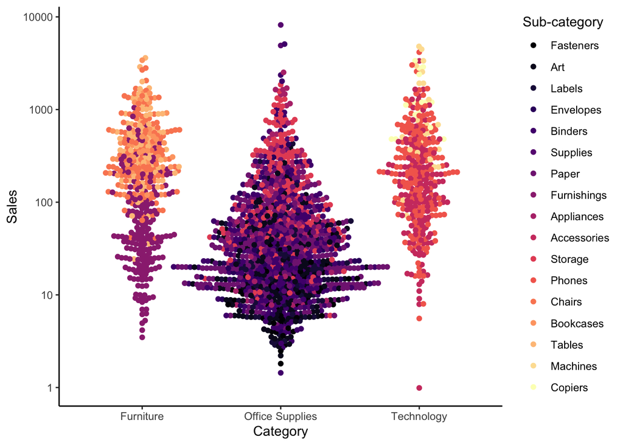